# Risk Factor Analysis

## Outcome Variable

**Outcome Variable:** haz

## Predictor Variables

**Intervention Variable:** nrooms

**Adjustment Set:**

- arm
- sex
- W_mage
- meducyrs
- feducyrs
- hhwealth_quart
- hfoodsec
- W_mhtcm
- W_mwtkg
- W_mbmi
- W_nchldlt5
- W_parity
- impfloor
- impsan
- safeh20
- delta_W_mage
- delta_meducyrs
- delta_feducyrs
- delta_hhwealth_quart
- delta_hfoodsec
- delta_W_mhtcm
- delta_W_mwtkg
- delta_W_mbmi
- delta_W_nchldlt5
- delta_W_parity
- delta_impfloor
- delta_impsan
- delta_safeh20

## Stratifying Variables

The analysis was stratified on these variable(s):

- agecat
- studyid
- country

## Data Summary

| agecat | studyid | country | nrooms | n_cell | n |
| --- | --- | --- | --- | --- | --- |
| Birth | CMC-V-BCS-2002 | INDIA | 4+ | 5 | 92 |
| Birth | CMC-V-BCS-2002 | INDIA | 1 | 38 | 92 |
| Birth | CMC-V-BCS-2002 | INDIA | 2 | 29 | 92 |
| Birth | CMC-V-BCS-2002 | INDIA | 3 | 20 | 92 |
| Birth | COHORTS | INDIA | 4+ | 92 | 4769 |
| Birth | COHORTS | INDIA | 1 | 3125 | 4769 |
| Birth | COHORTS | INDIA | 2 | 1385 | 4769 |
| Birth | COHORTS | INDIA | 3 | 167 | 4769 |
| Birth | CONTENT | PERU | 4+ | 1 | 2 |
| Birth | CONTENT | PERU | 1 | 0 | 2 |
| Birth | CONTENT | PERU | 2 | 1 | 2 |
| Birth | CONTENT | PERU | 3 | 0 | 2 |
| Birth | GMS-Nepal | NEPAL | 4+ | 321 | 696 |
| Birth | GMS-Nepal | NEPAL | 1 | 49 | 696 |
| Birth | GMS-Nepal | NEPAL | 2 | 145 | 696 |
| Birth | GMS-Nepal | NEPAL | 3 | 181 | 696 |
| Birth | IRC | INDIA | 4+ | 17 | 386 |
| Birth | IRC | INDIA | 1 | 175 | 386 |
| Birth | IRC | INDIA | 2 | 161 | 386 |
| Birth | IRC | INDIA | 3 | 33 | 386 |
| Birth | JiVitA-3 | BANGLADESH | 4+ | 755 | 22429 |
| Birth | JiVitA-3 | BANGLADESH | 1 | 13942 | 22429 |
| Birth | JiVitA-3 | BANGLADESH | 2 | 5846 | 22429 |
| Birth | JiVitA-3 | BANGLADESH | 3 | 1886 | 22429 |
| Birth | JiVitA-4 | BANGLADESH | 4+ | 128 | 2820 |
| Birth | JiVitA-4 | BANGLADESH | 1 | 1705 | 2820 |
| Birth | JiVitA-4 | BANGLADESH | 2 | 709 | 2820 |
| Birth | JiVitA-4 | BANGLADESH | 3 | 278 | 2820 |
| Birth | MAL-ED | BANGLADESH | 4+ | 12 | 213 |
| Birth | MAL-ED | BANGLADESH | 1 | 130 | 213 |

[output cut: 162 more lines]

The following strata were considered:

- agecat: 24 months, studyid: CMC-V-BCS-2002, country: INDIA
- agecat: 24 months, studyid: COHORTS, country: INDIA
- agecat: 24 months, studyid: CONTENT, country: PERU
- agecat: 24 months, studyid: GMS-Nepal, country: NEPAL
- agecat: 24 months, studyid: IRC, country: INDIA
- agecat: 24 months, studyid: JiVitA-3, country: BANGLADESH
- agecat: 24 months, studyid: JiVitA-4, country: BANGLADESH
- agecat: 24 months, studyid: MAL-ED, country: BANGLADESH
- agecat: 24 months, studyid: MAL-ED, country: BRAZIL
- agecat: 24 months, studyid: MAL-ED, country: INDIA
- agecat: 24 months, studyid: MAL-ED, country: NEPAL
- agecat: 24 months, studyid: MAL-ED, country: PERU
- agecat: 24 months, studyid: MAL-ED, country: SOUTH AFRICA
- agecat: 24 months, studyid: MAL-ED, country: TANZANIA, UNITED REPUBLIC OF
- agecat: 24 months, studyid: NIH-Crypto, country: BANGLADESH
- agecat: 24 months, studyid: PROVIDE, country: BANGLADESH
- agecat: 6 months, studyid: CMC-V-BCS-2002, country: INDIA
- agecat: 6 months, studyid: COHORTS, country: INDIA
- agecat: 6 months, studyid: CONTENT, country: PERU
- agecat: 6 months, studyid: GMS-Nepal, country: NEPAL
- agecat: 6 months, studyid: IRC, country: INDIA
- agecat: 6 months, studyid: JiVitA-3, country: BANGLADESH
- agecat: 6 months, studyid: JiVitA-4, country: BANGLADESH
- agecat: 6 months, studyid: MAL-ED, country: BANGLADESH
- agecat: 6 months, studyid: MAL-ED, country: BRAZIL
- agecat: 6 months, studyid: MAL-ED, country: INDIA
- agecat: 6 months, studyid: MAL-ED, country: NEPAL
- agecat: 6 months, studyid: MAL-ED, country: PERU
- agecat: 6 months, studyid: MAL-ED, country: SOUTH AFRICA
- agecat: 6 months, studyid: MAL-ED, country: TANZANIA, UNITED REPUBLIC OF
- agecat: 6 months, studyid: NIH-Crypto, country: BANGLADESH
- agecat: 6 months, studyid: PROVIDE, country: BANGLADESH
- agecat: Birth, studyid: CMC-V-BCS-2002, country: INDIA
- agecat: Birth, studyid: COHORTS, country: INDIA
- agecat: Birth, studyid: CONTENT, country: PERU
- agecat: Birth, studyid: GMS-Nepal, country: NEPAL
- agecat: Birth, studyid: IRC, country: INDIA
- agecat: Birth, studyid: JiVitA-3, country: BANGLADESH
- agecat: Birth, studyid: JiVitA-4, country: BANGLADESH
- agecat: Birth, studyid: MAL-ED, country: BANGLADESH
- agecat: Birth, studyid: MAL-ED, country: BRAZIL
- agecat: Birth, studyid: MAL-ED, country: INDIA
- agecat: Birth, studyid: MAL-ED, country: NEPAL
- agecat: Birth, studyid: MAL-ED, country: PERU
- agecat: Birth, studyid: MAL-ED, country: SOUTH AFRICA
- agecat: Birth, studyid: MAL-ED, country: TANZANIA, UNITED REPUBLIC OF
- agecat: Birth, studyid: NIH-Crypto, country: BANGLADESH
- agecat: Birth, studyid: PROVIDE, country: BANGLADESH

### Dropped Strata

Some strata were dropped due to rare outcomes:

- agecat: Birth, studyid: CONTENT, country: PERU
- agecat: Birth, studyid: MAL-ED, country: BRAZIL
- agecat: Birth, studyid: MAL-ED, country: INDIA
- agecat: Birth, studyid: MAL-ED, country: NEPAL
- agecat: 6 months, studyid: MAL-ED, country: BRAZIL
- agecat: 24 months, studyid: MAL-ED, country: BRAZIL

## Methods Detail

We’re interested in the causal parameters $E[Y_a]$ for all values of $a \in \mathcal{A}$. These parameters represent the mean outcome if, possibly contrary to fact, we intervened to set all units to have $A=a$. Under the randomization and positivity assumptions, these are identified by the statistical parameters $\psi_a=E_W[E_{Y|A,W}(Y|A=a,W)]$. In addition, we’re interested in the mean of $Y$, $E[Y]$ under no intervention (the observed mean). We will estimate these parameters by using SuperLearner to fit the relevant likelihood factors – $E_{Y|A,W}(Y|A=a,W)$ and $p(A=a|W)$, and then updating our likelihood fit using a joint TMLE.

For unadjusted analyses ($W=\{\}$), initial likelihoods were estimated using Lrnr_glm to estimate the simple $E(Y|A)$ and Lrnr_mean to estimate $p(A)$. For adjusted analyses, a small library containing Lrnr_glmnet, Lrnr_xgboost, and Lrnr_mean was used.

Having estimated these parameters, we will then use the delta method to estimate relative risks and attributable risks relative to a prespecified baseline level of $A$.

# Results Detail

## Results Plots

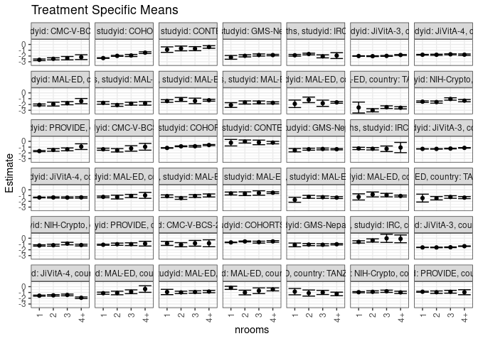

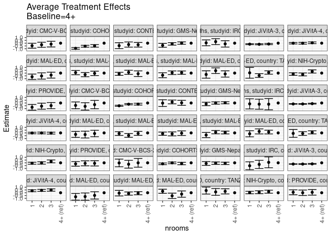

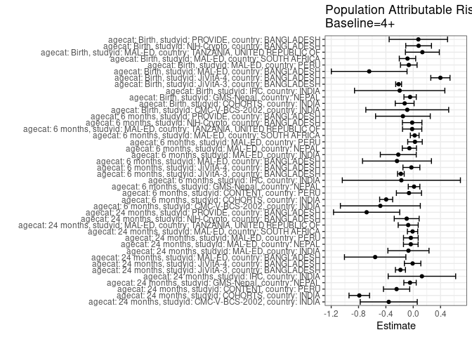

## Results Table

### Parameter: TSM

| agecat | studyid | country | intervention_level | baseline_level | estimate | ci_lower | ci_upper |
| --- | --- | --- | --- | --- | --- | --- | --- |
| Birth | CMC-V-BCS-2002 | INDIA | 4+ | NA | -0.8740000 | -1.4739904 | -0.2740096 |
| Birth | CMC-V-BCS-2002 | INDIA | 1 | NA | -0.8946053 | -1.2459292 | -0.5432813 |
| Birth | CMC-V-BCS-2002 | INDIA | 2 | NA | -1.1229310 | -1.4808250 | -0.7650370 |
| Birth | CMC-V-BCS-2002 | INDIA | 3 | NA | -0.8750000 | -1.3685904 | -0.3814096 |
| Birth | COHORTS | INDIA | 4+ | NA | -0.5527985 | -0.6910865 | -0.4145106 |
| Birth | COHORTS | INDIA | 1 | NA | -0.7238769 | -0.7667155 | -0.6810382 |
| Birth | COHORTS | INDIA | 2 | NA | -0.5576952 | -0.6316407 | -0.4837498 |
| Birth | COHORTS | INDIA | 3 | NA | -0.6749634 | -0.8360504 | -0.5138765 |
| Birth | GMS-Nepal | NEPAL | 4+ | NA | -1.0396151 | -1.1605409 | -0.9186894 |
| Birth | GMS-Nepal | NEPAL | 1 | NA | -1.1558692 | -1.4797681 | -0.8319703 |
| Birth | GMS-Nepal | NEPAL | 2 | NA | -1.0986849 | -1.2800062 | -0.9173637 |
| Birth | GMS-Nepal | NEPAL | 3 | NA | -1.1283809 | -1.3001553 | -0.9566065 |
| Birth | IRC | INDIA | 4+ | NA | -0.1099435 | -0.7853414 | 0.5654544 |
| Birth | IRC | INDIA | 1 | NA | -0.6352593 | -0.8340058 | -0.4365128 |
| Birth | IRC | INDIA | 2 | NA | -0.3901255 | -0.6700205 | -0.1102306 |
| Birth | IRC | INDIA | 3 | NA | -0.0203063 | -0.7241845 | 0.6835719 |
| Birth | JiVitA-3 | BANGLADESH | 4+ | NA | -1.3764633 | -1.4176465 | -1.3352800 |
| Birth | JiVitA-3 | BANGLADESH | 1 | NA | -1.5922262 | -1.6199363 | -1.5645161 |
| Birth | JiVitA-3 | BANGLADESH | 2 | NA | -1.5949733 | -1.6411585 | -1.5487880 |
| Birth | JiVitA-3 | BANGLADESH | 3 | NA | -1.5650567 | -1.6242504 | -1.5058629 |
| Birth | JiVitA-4 | BANGLADESH | 4+ | NA | -1.9215879 | -2.0616235 | -1.7815524 |
| Birth | JiVitA-4 | BANGLADESH | 1 | NA | -1.5588480 | -1.6539510 | -1.4637450 |
| Birth | JiVitA-4 | BANGLADESH | 2 | NA | -1.4967773 | -1.6202744 | -1.3732802 |
| Birth | JiVitA-4 | BANGLADESH | 3 | NA | -1.4299275 | -1.5775947 | -1.2822602 |
| Birth | MAL-ED | BANGLADESH | 4+ | NA | -0.4086964 | -0.9758406 | 0.1584477 |
| Birth | MAL-ED | BANGLADESH | 1 | NA | -1.1307112 | -1.3107602 | -0.9506622 |
| Birth | MAL-ED | BANGLADESH | 2 | NA | -1.0921492 | -1.4001609 | -0.7841376 |
| Birth | MAL-ED | BANGLADESH | 3 | NA | -0.8805454 | -1.2086136 | -0.5524772 |
| Birth | MAL-ED | PERU | 4+ | NA | -0.8493073 | -1.0487741 | -0.6498405 |
| Birth | MAL-ED | PERU | 1 | NA | -0.9208210 | -1.3785300 | -0.4631120 |

[output cut: 138 more lines]

### Parameter: E(Y)

| agecat | studyid | country | intervention_level | baseline_level | estimate | ci_lower | ci_upper |
| --- | --- | --- | --- | --- | --- | --- | --- |
| Birth | CMC-V-BCS-2002 | INDIA | NA | NA | -0.9611957 | -1.1776967 | -0.7446946 |
| Birth | COHORTS | INDIA | NA | NA | -0.6777626 | -0.7107167 | -0.6448086 |
| Birth | GMS-Nepal | NEPAL | NA | NA | -1.0851580 | -1.1651811 | -1.0051350 |
| Birth | IRC | INDIA | NA | NA | -0.3079016 | -0.4694769 | -0.1463262 |
| Birth | JiVitA-3 | BANGLADESH | NA | NA | -1.5898426 | -1.6091216 | -1.5705636 |
| Birth | JiVitA-4 | BANGLADESH | NA | NA | -1.5236135 | -1.5727559 | -1.4744711 |
| Birth | MAL-ED | BANGLADESH | NA | NA | -1.0530516 | -1.1896058 | -0.9164975 |
| Birth | MAL-ED | PERU | NA | NA | -0.9141395 | -1.0364098 | -0.7918693 |
| Birth | MAL-ED | SOUTH AFRICA | NA | NA | -0.5523958 | -0.7550074 | -0.3497843 |
| Birth | MAL-ED | TANZANIA, UNITED REPUBLIC OF | NA | NA | -1.1225000 | -1.3335666 | -0.9114334 |
| Birth | NIH-Crypto | BANGLADESH | NA | NA | -0.9094945 | -0.9809370 | -0.8380521 |
| Birth | PROVIDE | BANGLADESH | NA | NA | -0.8851020 | -0.9601332 | -0.8100709 |
| 6 months | CMC-V-BCS-2002 | INDIA | NA | NA | -1.4234508 | -1.5645974 | -1.2823042 |
| 6 months | COHORTS | INDIA | NA | NA | -1.0413281 | -1.0740395 | -1.0086167 |
| 6 months | CONTENT | PERU | NA | NA | -0.2785256 | -0.4098735 | -0.1471776 |
| 6 months | GMS-Nepal | NEPAL | NA | NA | -1.3508392 | -1.4290633 | -1.2726152 |
| 6 months | IRC | INDIA | NA | NA | -1.2470123 | -1.3779341 | -1.1160906 |
| 6 months | JiVitA-3 | BANGLADESH | NA | NA | -1.3132988 | -1.3364412 | -1.2901565 |
| 6 months | JiVitA-4 | BANGLADESH | NA | NA | -1.3440477 | -1.3813060 | -1.3067894 |
| 6 months | MAL-ED | BANGLADESH | NA | NA | -1.2026806 | -1.3203025 | -1.0850586 |
| 6 months | MAL-ED | INDIA | NA | NA | -1.2070638 | -1.3255909 | -1.0885368 |
| 6 months | MAL-ED | NEPAL | NA | NA | -0.5615819 | -0.6741832 | -0.4489807 |
| 6 months | MAL-ED | PERU | NA | NA | -1.3248549 | -1.4336721 | -1.2160378 |
| 6 months | MAL-ED | SOUTH AFRICA | NA | NA | -1.0547925 | -1.1843544 | -0.9252306 |
| 6 months | MAL-ED | TANZANIA, UNITED REPUBLIC OF | NA | NA | -1.3687449 | -1.4907629 | -1.2467270 |
| 6 months | NIH-Crypto | BANGLADESH | NA | NA | -1.1986783 | -1.2700937 | -1.1272630 |
| 6 months | PROVIDE | BANGLADESH | NA | NA | -1.0916915 | -1.1661176 | -1.0172654 |
| 24 months | CMC-V-BCS-2002 | INDIA | NA | NA | -2.5588679 | -2.6583730 | -2.4593629 |
| 24 months | COHORTS | INDIA | NA | NA | -2.2131714 | -2.2523749 | -2.1739679 |
| 24 months | CONTENT | PERU | NA | NA | -0.6868598 | -0.8388476 | -0.5348719 |
| 24 months | GMS-Nepal | NEPAL | NA | NA | -1.8874180 | -1.9728588 | -1.8019773 |
| 24 months | IRC | INDIA | NA | NA | -1.8014906 | -1.8952579 | -1.7077232 |
| 24 months | JiVitA-3 | BANGLADESH | NA | NA | -2.0137471 | -2.0414306 | -1.9860636 |
| 24 months | JiVitA-4 | BANGLADESH | NA | NA | -1.7803708 | -1.8158650 | -1.7448765 |
| 24 months | MAL-ED | BANGLADESH | NA | NA | -1.9783962 | -2.1050210 | -1.8517715 |
| 24 months | MAL-ED | INDIA | NA | NA | -1.8861894 | -2.0110006 | -1.7613783 |
| 24 months | MAL-ED | NEPAL | NA | NA | -1.3075877 | -1.4270718 | -1.1881037 |
| 24 months | MAL-ED | PERU | NA | NA | -1.7524710 | -1.8736426 | -1.6312994 |
| 24 months | MAL-ED | SOUTH AFRICA | NA | NA | -1.6450595 | -1.7797240 | -1.5103950 |
| 24 months | MAL-ED | TANZANIA, UNITED REPUBLIC OF | NA | NA | -2.6455607 | -2.7807256 | -2.5103959 |
| 24 months | NIH-Crypto | BANGLADESH | NA | NA | -1.4412646 | -1.5249156 | -1.3576135 |
| 24 months | PROVIDE | BANGLADESH | NA | NA | -1.6024221 | -1.6857420 | -1.5191023 |

### Parameter: ATE

| agecat | studyid | country | intervention_level | baseline_level | estimate | ci_lower | ci_upper |
| --- | --- | --- | --- | --- | --- | --- | --- |
| Birth | CMC-V-BCS-2002 | INDIA | 4+ | 4+ | 0.0000000 | 0.0000000 | 0.0000000 |
| Birth | CMC-V-BCS-2002 | INDIA | 1 | 4+ | -0.0206053 | -0.7158872 | 0.6746767 |
| Birth | CMC-V-BCS-2002 | INDIA | 2 | 4+ | -0.2489310 | -0.9475558 | 0.4496938 |
| Birth | CMC-V-BCS-2002 | INDIA | 3 | 4+ | -0.0010000 | -0.7779299 | 0.7759299 |
| Birth | COHORTS | INDIA | 4+ | 4+ | 0.0000000 | 0.0000000 | 0.0000000 |
| Birth | COHORTS | INDIA | 1 | 4+ | -0.1710783 | -0.3155439 | -0.0266127 |
| Birth | COHORTS | INDIA | 2 | 4+ | -0.0048967 | -0.1614859 | 0.1516925 |
| Birth | COHORTS | INDIA | 3 | 4+ | -0.1221649 | -0.3340837 | 0.0897539 |
| Birth | GMS-Nepal | NEPAL | 4+ | 4+ | 0.0000000 | 0.0000000 | 0.0000000 |
| Birth | GMS-Nepal | NEPAL | 1 | 4+ | -0.1162541 | -0.4614790 | 0.2289709 |
| Birth | GMS-Nepal | NEPAL | 2 | 4+ | -0.0590698 | -0.2765937 | 0.1584542 |
| Birth | GMS-Nepal | NEPAL | 3 | 4+ | -0.0887658 | -0.2980761 | 0.1205446 |
| Birth | IRC | INDIA | 4+ | 4+ | 0.0000000 | 0.0000000 | 0.0000000 |
| Birth | IRC | INDIA | 1 | 4+ | -0.5253158 | -1.2336849 | 0.1830533 |
| Birth | IRC | INDIA | 2 | 4+ | -0.2801821 | -1.0098932 | 0.4495291 |
| Birth | IRC | INDIA | 3 | 4+ | 0.0896372 | -0.8881386 | 1.0674130 |
| Birth | JiVitA-3 | BANGLADESH | 4+ | 4+ | 0.0000000 | 0.0000000 | 0.0000000 |
| Birth | JiVitA-3 | BANGLADESH | 1 | 4+ | -0.2157629 | -0.2639199 | -0.1676059 |
| Birth | JiVitA-3 | BANGLADESH | 2 | 4+ | -0.2185100 | -0.2783131 | -0.1587069 |
| Birth | JiVitA-3 | BANGLADESH | 3 | 4+ | -0.1885934 | -0.2586311 | -0.1185557 |
| Birth | JiVitA-4 | BANGLADESH | 4+ | 4+ | 0.0000000 | 0.0000000 | 0.0000000 |
| Birth | JiVitA-4 | BANGLADESH | 1 | 4+ | 0.3627399 | 0.1947260 | 0.5307539 |
| Birth | JiVitA-4 | BANGLADESH | 2 | 4+ | 0.4248106 | 0.2424871 | 0.6071341 |
| Birth | JiVitA-4 | BANGLADESH | 3 | 4+ | 0.4916605 | 0.2875433 | 0.6957776 |
| Birth | MAL-ED | BANGLADESH | 4+ | 4+ | 0.0000000 | 0.0000000 | 0.0000000 |
| Birth | MAL-ED | BANGLADESH | 1 | 4+ | -0.7220148 | -1.3179618 | -0.1260677 |
| Birth | MAL-ED | BANGLADESH | 2 | 4+ | -0.6834528 | -1.3291781 | -0.0377275 |
| Birth | MAL-ED | BANGLADESH | 3 | 4+ | -0.4718490 | -1.1268616 | 0.1831636 |
| Birth | MAL-ED | PERU | 4+ | 4+ | 0.0000000 | 0.0000000 | 0.0000000 |
| Birth | MAL-ED | PERU | 1 | 4+ | -0.0715137 | -0.5686826 | 0.4256553 |

[output cut: 138 more lines]

### Parameter: PAR

| agecat | studyid | country | intervention_level | baseline_level | estimate | ci_lower | ci_upper |
| --- | --- | --- | --- | --- | --- | --- | --- |
| Birth | CMC-V-BCS-2002 | INDIA | 4+ | NA | -0.0871957 | -0.6936048 | 0.5192134 |
| Birth | COHORTS | INDIA | 4+ | NA | -0.1249641 | -0.2628766 | 0.0129484 |
| Birth | GMS-Nepal | NEPAL | 4+ | NA | -0.0455429 | -0.1357181 | 0.0446323 |
| Birth | IRC | INDIA | 4+ | NA | -0.1979581 | -0.8591209 | 0.4632047 |
| Birth | JiVitA-3 | BANGLADESH | 4+ | NA | -0.2133793 | -0.2561821 | -0.1705766 |
| Birth | JiVitA-4 | BANGLADESH | 4+ | NA | 0.3979745 | 0.2574872 | 0.5384617 |
| Birth | MAL-ED | BANGLADESH | 4+ | NA | -0.6443552 | -1.1984551 | -0.0902554 |
| Birth | MAL-ED | PERU | 4+ | NA | -0.0648322 | -0.1863406 | 0.0566762 |
| Birth | MAL-ED | SOUTH AFRICA | 4+ | NA | -0.0835899 | -0.2035080 | 0.0363283 |
| Birth | MAL-ED | TANZANIA, UNITED REPUBLIC OF | 4+ | NA | 0.1342347 | -0.1139344 | 0.3824038 |
| Birth | NIH-Crypto | BANGLADESH | 4+ | NA | 0.0791206 | -0.1091945 | 0.2674357 |
| Birth | PROVIDE | BANGLADESH | 4+ | NA | 0.0754100 | -0.3519949 | 0.5028150 |
| 6 months | CMC-V-BCS-2002 | INDIA | 4+ | NA | -0.4809348 | -1.0659202 | 0.1040507 |
| 6 months | COHORTS | INDIA | 4+ | NA | -0.3959087 | -0.4910707 | -0.3007467 |
| 6 months | CONTENT | PERU | 4+ | NA | -0.0621523 | -0.2460033 | 0.1216986 |
| 6 months | GMS-Nepal | NEPAL | 4+ | NA | 0.0123912 | -0.0724913 | 0.0972737 |
| 6 months | IRC | INDIA | 4+ | NA | -0.1735354 | -1.0380413 | 0.6909706 |
| 6 months | JiVitA-3 | BANGLADESH | 4+ | NA | -0.1804918 | -0.2293442 | -0.1316395 |
| 6 months | JiVitA-4 | BANGLADESH | 4+ | NA | -0.0264246 | -0.1501945 | 0.0973454 |
| 6 months | MAL-ED | BANGLADESH | 4+ | NA | -0.2374336 | -0.7419087 | 0.2670416 |
| 6 months | MAL-ED | INDIA | 4+ | NA | -0.2184941 | -0.4813814 | 0.0443933 |
| 6 months | MAL-ED | NEPAL | 4+ | NA | -0.0560851 | -0.1597994 | 0.0476291 |
| 6 months | MAL-ED | PERU | 4+ | NA | 0.0259771 | -0.0803545 | 0.1323088 |
| 6 months | MAL-ED | SOUTH AFRICA | 4+ | NA | 0.0219058 | -0.0418568 | 0.0856684 |
| 6 months | MAL-ED | TANZANIA, UNITED REPUBLIC OF | 4+ | NA | -0.0152672 | -0.1563655 | 0.1258310 |
| 6 months | NIH-Crypto | BANGLADESH | 4+ | NA | -0.0151464 | -0.1579140 | 0.1276212 |
| 6 months | PROVIDE | BANGLADESH | 4+ | NA | -0.1506168 | -0.5509631 | 0.2497296 |
| 24 months | CMC-V-BCS-2002 | INDIA | 4+ | NA | -0.3581848 | -0.7756249 | 0.0592553 |
| 24 months | COHORTS | INDIA | 4+ | NA | -0.7892838 | -0.9396694 | -0.6388983 |
| 24 months | CONTENT | PERU | 4+ | NA | -0.2433587 | -0.4356909 | -0.0510266 |
| 24 months | GMS-Nepal | NEPAL | 4+ | NA | -0.0464696 | -0.1371004 | 0.0441613 |
| 24 months | IRC | INDIA | 4+ | NA | 0.1275330 | -0.3663491 | 0.6214151 |
| 24 months | JiVitA-3 | BANGLADESH | 4+ | NA | -0.1868786 | -0.2603255 | -0.1134317 |
| 24 months | JiVitA-4 | BANGLADESH | 4+ | NA | -0.0086008 | -0.1290600 | 0.1118583 |
| 24 months | MAL-ED | BANGLADESH | 4+ | NA | -0.5569616 | -1.0063042 | -0.1076191 |
| 24 months | MAL-ED | INDIA | 4+ | NA | -0.0697938 | -0.3707950 | 0.2312074 |
| 24 months | MAL-ED | NEPAL | 4+ | NA | -0.0354689 | -0.1426168 | 0.0716791 |
| 24 months | MAL-ED | PERU | 4+ | NA | -0.0344647 | -0.1419708 | 0.0730415 |
| 24 months | MAL-ED | SOUTH AFRICA | 4+ | NA | -0.0092825 | -0.0846765 | 0.0661114 |
| 24 months | MAL-ED | TANZANIA, UNITED REPUBLIC OF | 4+ | NA | -0.0733158 | -0.2199439 | 0.0733122 |
| 24 months | NIH-Crypto | BANGLADESH | 4+ | NA | -0.0953813 | -0.2776399 | 0.0868773 |
| 24 months | PROVIDE | BANGLADESH | 4+ | NA | -0.6819965 | -1.1663715 | -0.1976214 |